# presentation-live

## Stejné $F$, jiný biologický rozdíl

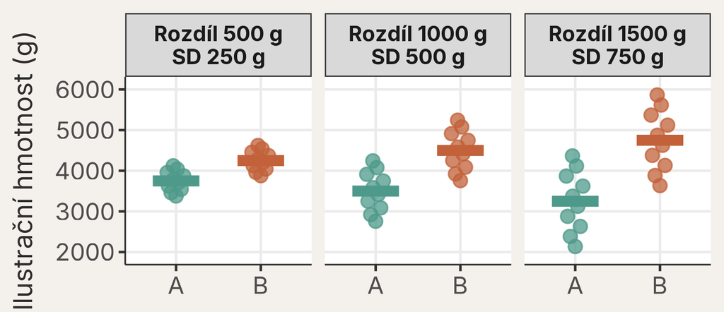

Všechny panely mají $F = \text{20}$. Jsou biologické závěry stejné?

## Malá p-hodnota neznamená velký efekt

Stejné

- poměr rozdílu k šumu;
- $F$-statistika;
- p-hodnota.

Jiné

- rozdíl v gramech;
- biologická relevance;
- praktický závěr.

Vždy uvádějte odhad efektu a jeho interval — ne pouze $p$-hodnotu.

# Které dvojice se liší?

## Od celkové otázky ke dvojicím

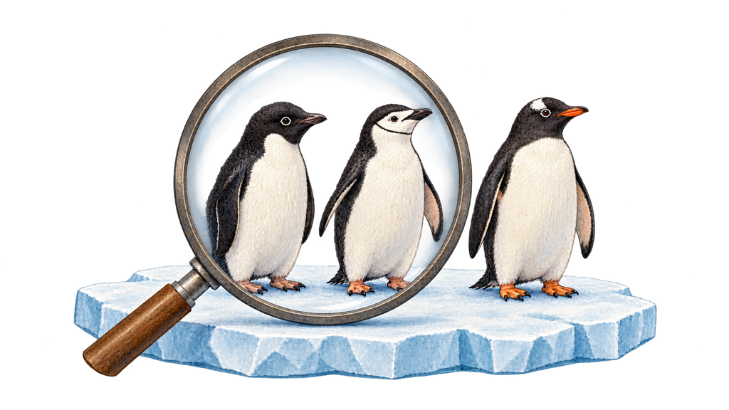

Ilustrace vytvořená pomocí AI.

ANOVA: „je někde rozdíl?“ → post-hoc porovnání: „mezi kterými dvojicemi?“

## Ze stejného modelu

Post-hoc otázky čteme ze stejného fitovaného modelu. Nefitujeme tři nové modely.

1. Model

`mod_tri`

2. Odhadnuté průměry

`emmeans()` pro každý druh

3. Párové rozdíly

`contrast()` s Tukeyho úpravou

## Kdy dávají párová porovnání smysl?

Dvě různé otázky položené stejnému modelu

- **Celkový F-test:** jsou všechny průměry stejné?
- **Post-hoc porovnání:** které dvojice se liší a o kolik gramů?
- Smysl mají u **tří a více skupin**; u dvou skupin odpovídá koeficient modelu.
- Tukeyho úprava sama zohlední, že porovnáváme více dvojic; nepotřebuje předchozí statisticky významný F-test.
- Malé rozdíly a nevýrazný F-test? Poctivý závěr je „nerozlišeno od nuly“, ne lovení jedné zajímavé dvojice.

## Post-hoc v R

```r
# Připomeneme si odhadnuté průměry ze stejného modelu
prumery_emm <-
  emmeans::emmeans(
    object = mod_tri,
    specs = ~druh
  )

# Rozdíly všech tří dvojic s Tukeyho úpravou
post_hoc_tri <-
  emmeans::contrast(
    object = prumery_emm,
    method = "revpairwise",
    adjust = "tukey"
  )
```

`method` určuje směr rozdílů, například Gentoo minus Adélie; `adjust` říká, že tři navazující otázky hodnotíme společně.

## Výsledek post-hoc porovnání

```r
summary(object = post_hoc_tri)
```

```
 contrast           estimate   SE  df t.ratio p.value
 Chinstrap - Adelie     32.4 67.5 339   0.480  0.8807
 Gentoo - Adelie      1375.4 56.1 339  24.495 <0.0001
 Gentoo - Chinstrap   1342.9 69.9 339  19.224 <0.0001

P value adjustment: tukey method for comparing a family of 3 estimates
```

Chinstrap − Adélie

Rozdíl 32 g, upravená p-hodnota 0,881: data rozdíl neodlišují od nuly.

Gentoo − Adélie a Gentoo − Chinstrap

Rozdíly 1 375 g a 1 343 g, obě upravené p-hodnoty < 0,001.

## Tři rozdíly na jedné ose

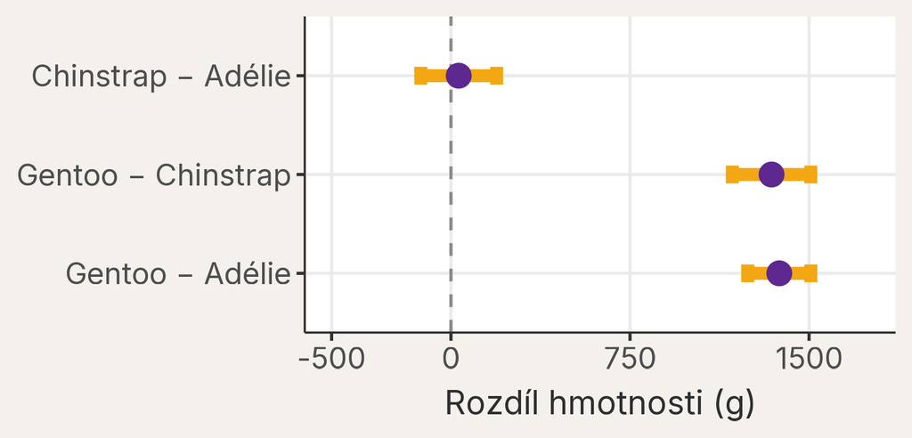

Tukeyho simultánní 95% intervaly: všechna tři porovnání jsou vyhodnocena společně.

Diskuse ve dvojici

Který interval obsahuje nulu? Jak to souvisí s výsledkem celkového F-testu?

## Co jsme zjistili?

Gentoo

Je v průměru asi o **1 343–1 375 g těžší** než Adélie i Chinstrap.

Adélie vs. Chinstrap

Odhad rozdílu je jen asi **32 g** a interval obsahuje nulu.

Statisticky významná ANOVA neznamená, že se liší každá dvojice.

# Závěr

## Druh není celý příběh

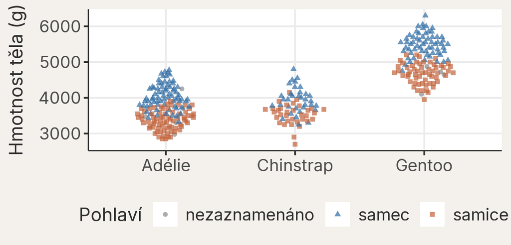

Model s jediným prediktorem odpovídá jedné otázce. Hmotnost souvisí také s pohlavím.

Druh je navíc propojený s ostrovem: Chinstrap byli měřeni jen na ostrově Dream, Gentoo jen na Biscoe.

## Co kdybychom přidali pohlaví nebo ostrov?

Tato lekce

Jeden kategoriální prediktor: druh.

Efekt: **rozdíl průměrů vůči referenční skupině**.

Následující lekce

Více prediktorů v jednom modelu: například druh a pohlaví.

Efekt: **rozdíl při zohlednění ostatních prediktorů**.

Změní se odhad rozdílu mezi druhy, když budeme porovnávat tučňáky stejného pohlaví?

## Shrnutí

- Kategoriální prediktor vstupuje do `lm()` pomocí přepínačů 0/1.
- Intercept je průměr referenční skupiny, ostatní koeficienty jsou rozdíly vůči ní.
- Dvouvýběrový t-test je test koeficientu dvouskupinového modelu.
- ANOVA porovnává variabilitu mezi skupinami s variabilitou uvnitř nich; celkový F-test neříká, která dvojice se liší.
- Post-hoc porovnání odpovídají na otázky o konkrétních dvojicích a Tukeyho úprava zohlední, že jich je více.

Rozdíl v gramech → interval → test → omezení studie

## Co potřebujete vědět, než napíšete „druh určuje hmotnost tučňáka“?

Jaké tři otázky položíte autorovi, který vám ukáže jen tuto větu a malou p-hodnotu ANOVA?

Řekněte sousedovi jednou větou

Kterou z otázek byste položili jako první, a proč?